# MIF Results — Round 1

Andrew Tredennick

11 September, 2018

## Overview

This is a report on the first round of results from fitting the stochastic SIR model to data from Niamey using iterated filtering (MIF), as implemented in `pomp::mif2()`. I started the analysis by making a Latin hypercube sample of parameter values (1000 parameter sets) that served as initial conditions for iterated filtering. I ran `pomp::mif2()` for all 1000 initial conditions for 50 MIF itertations with 2000 particles and the cooling factor set to 1 (i.e., no cooling). At the final iteration, I ran 10 replicate instances of `pomp::pfilter()` to estimate the log likelihood of the parameters for each of the 1000 MIF estimates and the Monte carlo error. There were some errors in running all 1000 MIFs in parallel on Olympus (still looking into this), but I got back 742 MIF estimates.

## Results

#### Traceplots of the iterated filtering paths for the parameter sets with the 200 highest log likelihoods

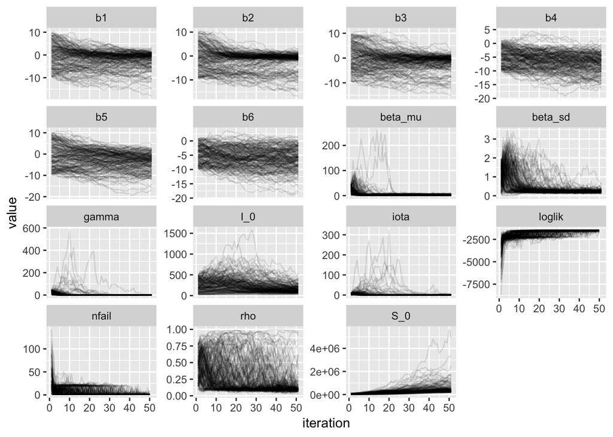

#### Parameter estimates with the highest log likelihood

Note that the model was fit with a time-step of 1 day (`delta.t = 1/365`).

| loglik | loglik_se | beta_mu | gamma | beta_sd | b1 | b2 | b3 | b4 | b5 | b6 | iota | rho | S_0 | I_0 |
| --- | --- | --- | --- | --- | --- | --- | --- | --- | --- | --- | --- | --- | --- | --- |
| -1468.96 | 1.19 | 2.62 | 1.24 | 0.25 | -0.17 | -1.18 | 0.34 | -7.86 | -11.83 | -4.64 | 1 | 0.11 | 268610 | 114.39 |

#### Model simulations at the (current) MLEs

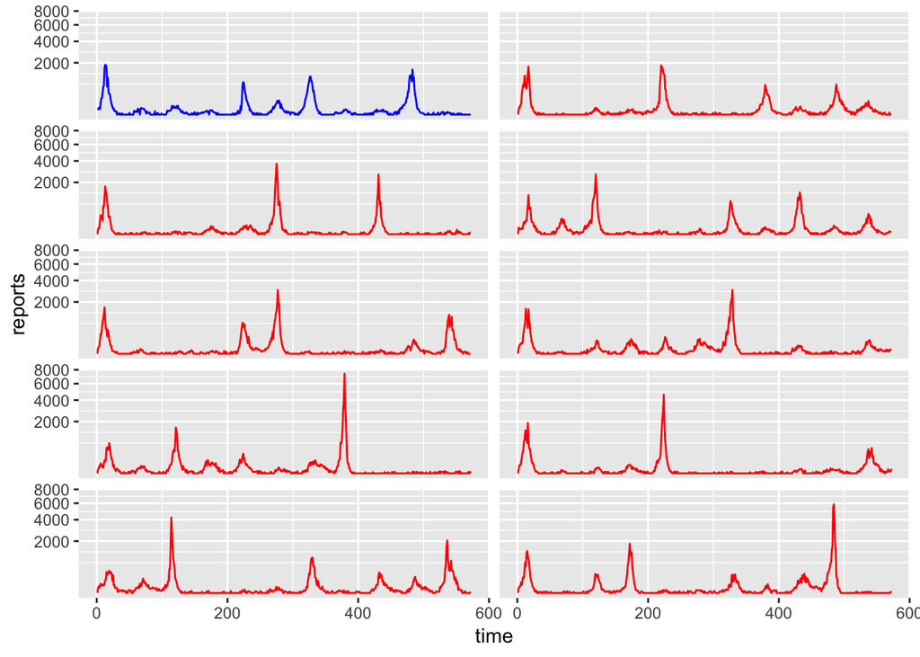

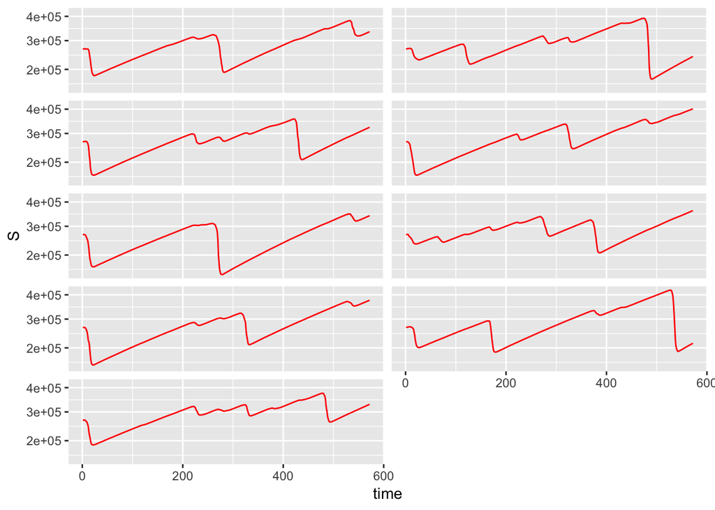

## Thoughts

I’m actually quite pleased with the simulated dynamics! I’m not quite as pleased with the estimates of the number of susceptibles. The model *really* wants those to be much higher than I would expect.